# How to use the `coxed` function

Jonathan Kropko and Jeffrey J. Harden

2019-03-22

# 1 Introduction

The Cox proportional hazards model (implemented in R as `coxph()` in the `survival` package or as `cph()` `rms` package) is one of the most frequently used estimators in duration (survival) analysis. Because it is estimated using only the observed durations’ rank ordering, typical quantities of interest used to communicate results of the Cox model come from the hazard function (e.g., hazard ratios or percentage changes in the hazard rate). These quantities are substantively vague and difficult for many audiences of research to understand. The `coxed` package introduces a suite of methods to address these problems. The package allows researchers to calculate duration-based quantities from Cox model results, such as the expected duration (or survival time) given covariate values and marginal changes in duration for a specified change in a covariate. These duration-based quantities often match better with researchers’ substantive interests and are easily understood by most readers. This document is a walkthrough of the examples included in the help documentation for the `coxed()` function.

Before we begin, we load the `coxed` package,

```r
library(coxed)
```

and packages from the `tidyverse` for managing and plotting data as we go:

```r
library(dplyr)
library(tidyr)
library(ggplot2)
```

# 2 Running a Cox proportional hazards model

The following quote from Kropko and Harden (2018) sets up our first working example:

> Martin and Vanberg (2003) examine the determinants of negotiation time among political parties forming a coalition government. . . . The dependent variable in Martin and Vanberg’s analysis is the number of days between the beginning and end of the bargaining period. Martin and Vanberg model this variable as a function of the Range of government, which is a measure of the ideological distance between the extreme members of the coalition, the Number of government parties in the coalition, and several other variables. They interact Number of government parties with the natural log of time because that variable violates the proportional hazards assumption. Their hypotheses predict negative coefficients on the variables of interest, indicating that increases in the ideological distance between the parties and in the number of parties correspond with a decrease in the risk of government formation, or a longer negotiation time.

The authors demonstrate support for their hypotheses by computing changes in the hazard rate based on changes to these independent variables. However, to assess what the estimated effects of Range of government and Number of government parties mean in substantive terms, we use `coxed()` to predict how long is each case predicted to last. We will also find answers to the following questions about duration:

- How much longer will negotiations take for an ideologically polarized coaltion as compared to an ideologically homogeneous one?
- How much longer will negotiations take for a multiparty coalition government than for a single-party government?

First we replicate the Cox model from Martin and Vanberg (2003):

```r
mv.surv <- Surv(martinvanberg$formdur, event = rep(1, nrow(martinvanberg)))
mv.cox <- coxph(mv.surv ~ postel + prevdef + cont + ident + rgovm + pgovno +
                     tpgovno + minority, method = "breslow", data = martinvanberg)
summary(mv.cox)
```

```
## Call:
## coxph(formula = mv.surv ~ postel + prevdef + cont + ident + rgovm +
##     pgovno + tpgovno + minority, data = martinvanberg, method = "breslow")
##
##   n= 203, number of events= 203
##
##              coef exp(coef) se(coef)       z Pr(>|z|)
## postel   -0.57665   0.56177  0.16862  -3.420 0.000627 ***
## prevdef  -0.10000   0.90484  0.22987  -0.435 0.663543
## cont      1.10047   3.00556  0.23970   4.591 4.41e-06 ***
## ident     0.14579   1.15695  0.11859   1.229 0.218938
## rgovm    -0.21312   0.80806  0.12036  -1.771 0.076625 .
## pgovno    1.19057   3.28894  0.12405   9.598  < 2e-16 ***
## tpgovno  -0.43189   0.64928  0.03476 -12.425  < 2e-16 ***
## minority -0.42759   0.65208  0.20793  -2.056 0.039740 *
## ---
## Signif. codes:  0 '***' 0.001 '**' 0.01 '*' 0.05 '.' 0.1 ' ' 1
##
##          exp(coef) exp(-coef) lower .95 upper .95
## postel      0.5618     1.7801    0.4037    0.7818
## prevdef     0.9048     1.1052    0.5766    1.4198
## cont        3.0056     0.3327    1.8789    4.8079
## ident       1.1570     0.8643    0.9170    1.4597
## rgovm       0.8081     1.2375    0.6382    1.0231
## pgovno      3.2889     0.3040    2.5791    4.1942
## tpgovno     0.6493     1.5402    0.6065    0.6951
## minority    0.6521     1.5336    0.4338    0.9801
##
## Concordance= 0.903  (se = 0.025 )
## Rsquare= 0.745   (max possible= 1 )
## Likelihood ratio test= 277.2  on 8 df,   p=<2e-16
## Wald test            = 218.1  on 8 df,   p=<2e-16
## Score (logrank) test = 279.3  on 8 df,   p=<2e-16
```

Next we will use the both versions of `coxed()` to examine expected durations and marginal changes in duration.

# 3 Using the NPSF method within the `coxed()` function

## 3.1 Without standard errors

To see predicted durations from the Cox model, place the Cox model output as the first argument of `coxed()`:

```r
ed1 <- coxed(mv.cox, method="npsf")
```

There are a number of uses of the `coxed()` output. First, the predicted durations for each individual observation are stored in the `exp.dur` attribute:

```r
head(ed1$exp.dur)
```

```
##     exp.dur
## 1 34.620664
## 2 31.639975
## 3 39.509093
## 4 14.717544
## 5  2.473799
## 6 47.347670
```

The `summary()` function, when applied to `coxed`, reports either the mean or median duration in the estimation sample, depending on the option specified with `stat`:

```r
summary(ed1, stat="mean")
```

```
##  mean
## 25.18
```

```r
summary(ed1, stat="median")
```

```
## median
## 19.121
```

The predicted mean duration of government negotiations is 25.18 days, and the predicted median duration is 19.12 days.

In addition to reporting the mean and median duration, the NPSF version of `coxed()` provides estimates of the cumulative baseline hazard function and the baseline survivor function in the data. These functions are stored as a data frame in the `baseline.functions` attribute.

```r
head(ed1$baseline.functions)
```

```
##   time        cbh  survivor
## 1    1 0.01631230 0.9838200
## 2    2 0.03587341 0.9647624
## 3    3 0.04746259 0.9536462
## 4    4 0.07651484 0.9263392
## 5    5 0.09169880 0.9123799
## 6    6 0.12573075 0.8818522
```

We can plot these baseline functions with `ggplot()`:

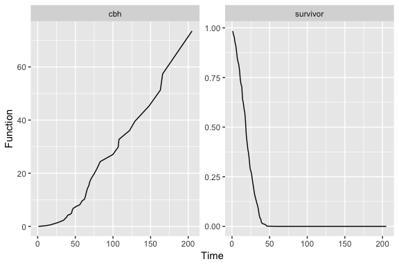

```r
baseline <- gather(ed1$baseline.functions, cbh, survivor, key="survivefunction", value="value")
ggplot(baseline, aes(x=time, y=value)) +
     geom_line() +
     xlab("Time") +
     ylab("Function") +
     facet_wrap( ~ survivefunction, scales = "free")
```

## 3.2 With (bootstrapped) standard errors

We can calculate standard errors and confidence intervals for any of these quantities with the `bootstrap=TRUE` option. By default the bootstrapping procedure uses 200 iterations (to set this value to a different number, use the `B` argument). Here we use 30 iterations simply to ease the computational burden of compiling this vignette. For more reliable results, set `B` to a higher value:

```r
ed1 <- coxed(mv.cox, method="npsf", bootstrap = TRUE, B=30)
```

Now every predicted duration has a standard error and a 95% confidence interval.

```r
head(ed1$exp.dur)
```

```
##     exp.dur bootstrap.se        lb       ub
## 1 34.620664    1.0757338 32.512264 36.72906
## 2 31.639975    0.9236906 29.829575 33.45038
## 3 39.509093    1.5278990 36.514466 42.50372
## 4 14.717544    0.6088491 13.524221 15.91087
## 5  2.473799    0.3889717  1.711428  3.23617
## 6 47.347670    2.7584965 41.941116 52.75422
```

The mean and median also have standard errors and confidence intervals.

```r
summary(ed1, stat="mean")
```

```
##   mean bootstrap.se     lb     ub
##  25.18        1.099 23.026 27.333
```

```r
summary(ed1, stat="median")
```

```
##  median bootstrap.se     lb     ub
##  19.121        0.662 17.823 20.418
```

To change the confidence interval to a different level, use the `level` argument:

```r
ed1 <- coxed(mv.cox, method="npsf", bootstrap = TRUE, B=30, level=.8)
summary(ed1, stat="mean")
```

```
##   mean bootstrap.se     lb     ub
##  25.18        1.291 23.525 26.835
```

```r
summary(ed1, stat="median")
```

```
##  median bootstrap.se     lb     ub
##  19.121        0.865 18.012 20.229
```

```r
ed1 <- coxed(mv.cox, method="npsf", bootstrap = TRUE, B=30, confidence="empirical")
summary(ed1, stat="mean")
```

```
##   mean bootstrap.se     lb     ub
##  25.18        1.152 22.779 27.081
```

```r
summary(ed1, stat="median")
```

```
##  median bootstrap.se   lb     ub
##  19.121        0.763 17.7 21.058
```